# More Fisher information exploration

```python
import matplotlib as mpl
import matplotlib.pyplot as plt
%matplotlib inline
from IPython.core.pylabtools import figsize

import seaborn as sns
import plotly.express as px

import numpy as np
import pandas as pd
import polars as pl

import statsmodels.formula.api as smf

import torch
```

```python
# load the trained model
from datageneration.stimulusGeneration import generateGrating
from basicModel import EstimateAngle

from experiments.ex2_sensitivity_scaling import dataFile_Experiment2

# training data parameters
pixelDim = 101
shotNoise = 0.8
noiseVar = 20

# training data distribution
dataSize = 512
kappa_tr = 4.
loc_tr = 0.
rep = 0


fileName = dataFile_Experiment2(dataSize, kappa_tr, loc_tr, rep)
trained_model = EstimateAngle.load_from_checkpoint(fileName)
```

```python
fileName
```

```
'trainedParameters/Experiment2/380931818027565204/epoch=208-step=26752.ckpt'
```

## Full derivatives

```python
# different derivative techniques
from scipy.interpolate import splev, splrep, splprep
from scipy.signal import savgol_filter
from tvregdiff.tvregdiff import TVRegDiff
```

```python
angles = np.linspace(0, np.pi, 10000)

noisy_results = trained_model.forward(
                            generateGrating(angles, pixelDim=pixelDim, shotNoise=shotNoise,
                                            noiseVar=noiseVar)
                    ).detach().numpy()
```

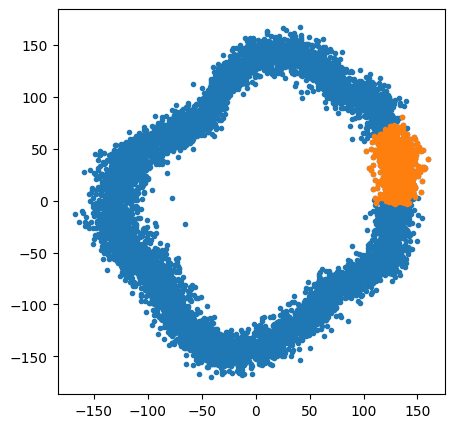

```python
figsize(5,5)
plt.plot(noisy_results[:,0], noisy_results[:,1], '.')
plt.plot(noisy_results[0:800, 0], noisy_results[0:800, 1], '.')
```

```python
fits0 = savgol_filter(noisy_results[:,0], window_length=400, polyorder=2, mode='wrap')
fits1 = savgol_filter(noisy_results[:,1], window_length=400, polyorder=2, mode='wrap')
```

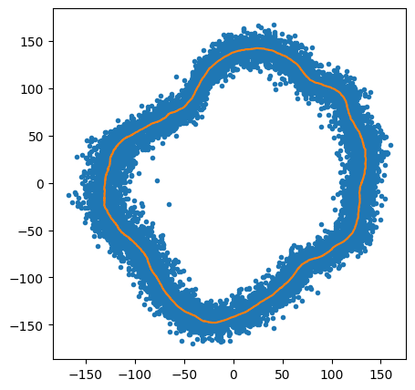

```python
plt.plot(noisy_results[:,0], noisy_results[:,1], '.')
plt.plot(fits0, fits1)
```

```python
derivs0 = savgol_filter(noisy_results[:,0], window_length=300, polyorder=2, deriv=1, mode='wrap', delta=angles[1]-angles[0])
derivs1 = savgol_filter(noisy_results[:,1], window_length=300, polyorder=2, deriv=1, mode='wrap', delta=angles[1]-angles[0])

derivs0_larger = savgol_filter(noisy_results[:,0], window_length=400, polyorder=2, deriv=1, mode='wrap', delta=angles[1]-angles[0])
derivs1_larger = savgol_filter(noisy_results[:,1], window_length=400, polyorder=2, deriv=1, mode='wrap', delta=angles[1]-angles[0])
```

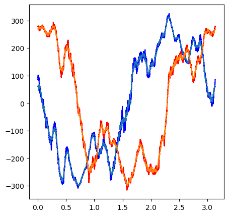

```python
plt.plot(angles, derivs0, 'b')
plt.plot(angles, derivs1, 'r')

plt.plot(angles, derivs0_larger, '--')
plt.plot(angles, derivs1_larger, '--')
```

These certainly seem good enough. It'd be nice to confirm that they at least line up with another method.

```python
splinerep, u = splprep([noisy_results[:,0], noisy_results[:,1]], u=angles, s=990000)
```

```python
a, b = splev(np.linspace(0, np.pi, 2000), splinerep)
```

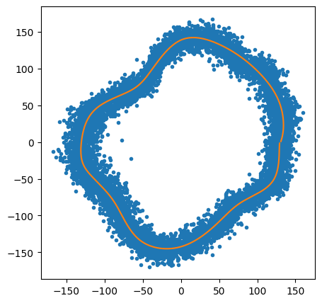

```python
plt.plot(noisy_results[:,0], noisy_results[:,1], '.')
plt.plot(a,b)
```

On point for the savgol filter: spline fits are sloooow

```python
theta_eval = np.linspace(0, np.pi, 2000)
spline_derivs = splev(theta_eval, splinerep, der=1)
```

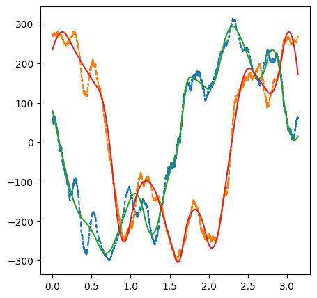

```python
plt.plot(angles, derivs0_larger, '--')
plt.plot(angles, derivs1_larger, '--')

plt.plot(theta_eval, spline_derivs[0])
plt.plot(theta_eval, spline_derivs[1])
```

Broadly speaking, they do agree. The Savgol, of course has some additional structure around the spline.

```python
derivs0_verysmooth = savgol_filter(noisy_results[:,0], window_length=700, polyorder=2, deriv=1, mode='wrap', delta=angles[1]-angles[0])
derivs1_verysmooth = savgol_filter(noisy_results[:,1], window_length=700, polyorder=2, deriv=1, mode='wrap', delta=angles[1]-angles[0])
```

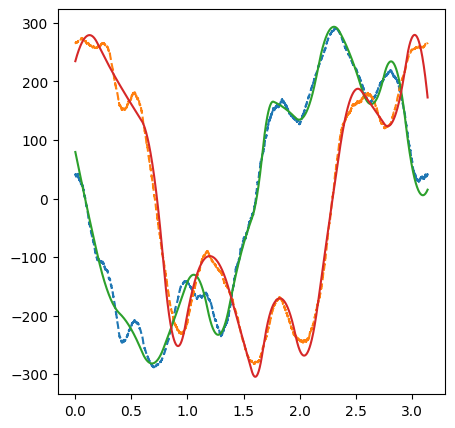

```python
plt.plot(angles, derivs0_verysmooth, '--')
plt.plot(angles, derivs1_verysmooth, '--')

plt.plot(theta_eval, spline_derivs[0])
plt.plot(theta_eval, spline_derivs[1])
```

Yeah, we can always smooth more. Good enough.

## Now the covariances

```python
angles = np.linspace(0, np.pi, 500)

covs = []
for angle in angles:
    noisy_results = trained_model.forward(
                                generateGrating(5000*[angle], pixelDim=pixelDim, shotNoise=shotNoise,
                                                noiseVar=noiseVar)
                        ).detach().numpy()

    print(angle)

    covs.append(np.cov(noisy_results.T))
```

[output not shown]

[output cut: 445 more lines]

[output not shown]

```python
cp = (covs[2] - covs[0]) / ( angles[2] - angles[0])
```

```python
np.trace( cp @ np.linalg.inv(covs[1]) @ cp @ np.linalg.inv(covs[1]))
```

```
84.8396206758675
```

```python
deriv = np.array([derivs0_verysmooth[1], derivs1_verysmooth[1]])
```

```python
deriv.T @ np.linalg.inv(covs[1]) @ deriv
```

```
8908.307093829468
```

But in comparison the derivative term...

```python
derivs0_verysmooth.shape
```

```
(10000,)
```

```python
angles_deriv = np.linspace(0, np.pi, 10000)
angles_cov = np.linspace(0, np.pi, 500)
```

```python
angles_cov[1]
```

```
0.006295776860901389
```

```python
angles_deriv[20]
```

```
0.006283813688548441
```

```python
deriv_cov_ratio = 10000 // 500

derivs =  np.array( [derivs0_verysmooth, derivs1_verysmooth])

def make_Fisher_Info(derivs, covs, deriv_cov_ratio=deriv_cov_ratio):
    """ """
    FI = []
    for i, cov in enumerate(covs):
        FI.append(derivs[:, deriv_cov_ratio*i] @ np.linalg.inv(cov) @ derivs[:, deriv_cov_ratio*i])

    return np.array(FI)
```

```python
FI = make_Fisher_Info(derivs, covs)
```

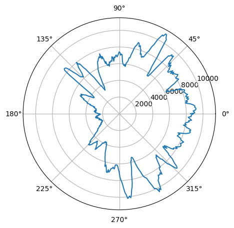

```python
fig, ax = plt.subplots(subplot_kw={'projection': 'polar'})
plt.plot(2*angles_cov, FI)
```

Ok. First of all, this is pretty consistent with the previous estimate in Experiments 3. The main question is: how successful were we in decreasing the variance?

Also: how do the different Fisher information measurement techniques compare to one-another.

## How much variances is there?

```python
from discriminationAnalysis import Fisher_smooth_fits
```

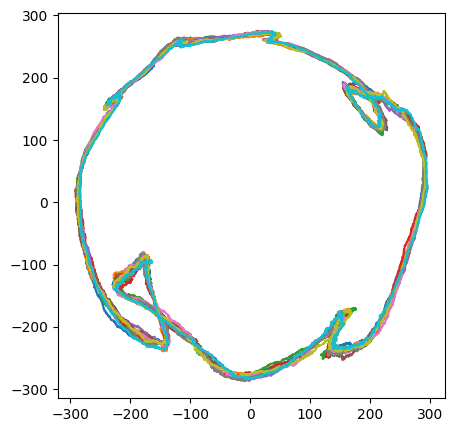

```python
from datageneration.stimulusGeneration import generateGrating

from scipy.signal import savgol_filter
from discriminationAnalysis import generate_samples


theta_start = 0.
theta_end = np.pi
N_mean = 10000

model = trained_model

figsize(5,5)

for i in range(10):
    mean_angles = np.linspace(theta_start, theta_end, N_mean)
    neural_activity = generate_samples(model, mean_angles)

    derivs0 = savgol_filter(neural_activity[:, 0],
                            window_length=700, polyorder=2, deriv=1,
                            mode='wrap', delta=mean_angles[1]-mean_angles[0])
    derivs1 = savgol_filter(neural_activity[:, 1],
                            window_length=700, polyorder=2, deriv=1,
                            mode='wrap', delta=mean_angles[1]-mean_angles[0])

    plt.plot(derivs0, derivs1)
```

This is good to see. There is fairly little variance between samples for the derivatives.

```python
for i in range(10):
    noisy_results = generate_samples(model,  1000*[0])

    invcov = np.linalg.inv(np.cov(noisy_results.T))

    print(invcov)
```

```
[[ 0.01405398 -0.00662514]
 [-0.00662514  0.12630272]]
[[ 0.01409421 -0.00703786]
 [-0.00703786  0.1205217 ]]
[[ 0.01477997 -0.0079318 ]
 [-0.0079318   0.12996504]]
[[ 0.01475744 -0.00704761]
 [-0.00704761  0.12590392]]
[[ 0.01536408 -0.00702781]
 [-0.00702781  0.13739429]]
[[ 0.01511553 -0.00729761]
 [-0.00729761  0.13044892]]
[[ 0.01467258 -0.00965201]
 [-0.00965201  0.12256881]]
[[ 0.01389012 -0.00629394]
 [-0.00629394  0.13339511]]
[[ 0.01426755 -0.00638191]
 [-0.00638191  0.12253412]]
[[ 0.01442344 -0.00554336]
 [-0.00554336  0.12186778]]
```

[output not shown]

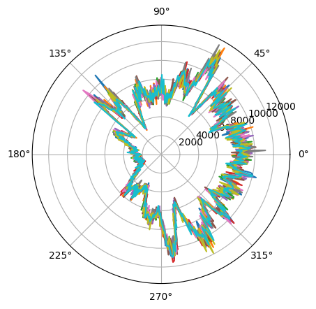

```python
fig, ax = plt.subplots(subplot_kw={'projection': 'polar'})
angles_cov = np.linspace(0, np.pi,500)

for i in range(10):
    FI = Fisher_smooth_fits(trained_model, 0, np.pi, N_cov=500, Samp_cov=500)
    plt.plot(2*angles_cov, FI)
    print(i)
```

Ok. This is great. The variance between samples seems pretty low actually.

### Comparison of different methods for determining the Fisher information

Here, I want to see that the different Fisher information measurement techniques are broadly consistent across several stimulus points.